# Análisis de variables clínicas para la detección de diabetes

En este ejercicio, contamos con información acerca de distintos pacientes con características clínicas (número de embarazos, glucosa, presión arterial, grosor del pliegue cutáneo, insulina, índice de masa corporal y función del pedigrí de diabetes) y si desarrollaron o no diabetes. Nuestro objetivo es identificar cuál o cuáles de estas variables son más significativas para determinar si el paciente presenta la enfermedad.

Aplicamos una serie de métodos para identificar el mejor modelo según el AIC. Para ello, utilizamos la familia binomial con tres ligas: logit, probit y cloglog. Además, consideramos tres métodos de selección de variables: mejor subconjunto, método forward y penalización Lasso. Por último, realizamos un preprocesamiento en el que aplicamos el logaritmo a algunas variables.

Para presentar los resultados de manera clara, mostramos la siguiente tabla:

Con liga logit:

| Preprocesamiento | Modelo | AIC |
| --- | --- | --- |
| No | Mejor subconjunto: componentes principales | 356.88 |
| No | Step forward: componentes principales | 357.23 |
| No | lasso: componentes principales | 357.06 |
| No | Step forward: interacciones y cadrados | 346.80 |
| No | lasso: interacciones y cuadrados | 338.34 |
| logaritmo | Mejor subconjunto: componentes principales | 350.72 |
| logaritmo | Step forward: interacciones y cuadrados | 348.92 |
| logaritmo | lasso: componentes principales | 350.75 |
| logaritmo | lasso: interacciones y cuadrados | 349.87 |

Con liga probit:

| Preprocesamiento | Modelo | AIC |
| --- | --- | --- |
| No | Mejor subconjunto: componentes principales | 357.55 |
| No | Step forward: interacciones y cadrados | 351.39 |
| No | lasso: componentes principales | 357.86 |
| No | lasso: interacciones y cuadrados | 342.83 |
| logaritmo | Mejor subconjunto: componentes principales | 351.78 |
| logaritmo | Step forward: interacciones y cuadrados | 350.16 |
| logaritmo | lasso: componentes principales | 351.82 |
| logaritmo | lasso: interacciones y cuadrados | 354.58 |

Con liga cloglog:

| Preprocesamiento | Modelo | AIC |
| --- | --- | --- |
| No | Mejor subconjunto: componentes principales | 367.53 |
| No | Step forward: interacciones y cadrados | 370.18 |
| No | lasso: componentes principales | 371.09 |
| No | lasso: interacciones y cuadrados | 355.75 |
| logaritmo | Mejor subconjunto: componentes principales | 362.70 |
| logaritmo | Step forward: interacciones y cuadrados | 350.15 |
| logaritmo | lasso: componentes principales | 364.06 |
| logaritmo | lasso: interacciones y cuadrados | 354.56 |

Ahora, con el de menor AIC procedemos a ajustar un modelo utilizando la familia binomial con liga logit, penalización lasso y considerando componentes principales, interacciones y términos cuadráticos. Como resultado, obtenemos las siguientes variables:

```
##        Intercept          glucose         pressure             mass
##    -1.601518e+01     4.124610e-02    -8.473728e-02     3.010031e-01
##         pedigree              age pregnant_glucose     pregnant_age
##     2.504731e+00     2.776200e-01    -1.780243e-03     4.574599e-03
## glucose_pressure  glucose_triceps     glucose_mass pressure_insulin
##     5.161883e-04     8.360759e-04    -1.588445e-03    -1.179662e-04
##     pressure_age     triceps_mass      triceps_age insulin_pedigree
##     1.292155e-03    -1.262052e-03    -1.456823e-03    -5.551321e-03
##      insulin_age      pregnant_sq       insulin_sq           age_sq
##     4.422924e-04     9.762382e-03    -5.032242e-06    -5.285504e-03
```

Observamos que, a medida que aumentan la glucosa,presión arterial,el índice de masa corporal, la predisposición hereditaria a desarrollar la enfermedad y la edad, también aumenta la probabilidad de padecer diabetes. Esto se puede visualizar claramente en las siguientes gráficas.

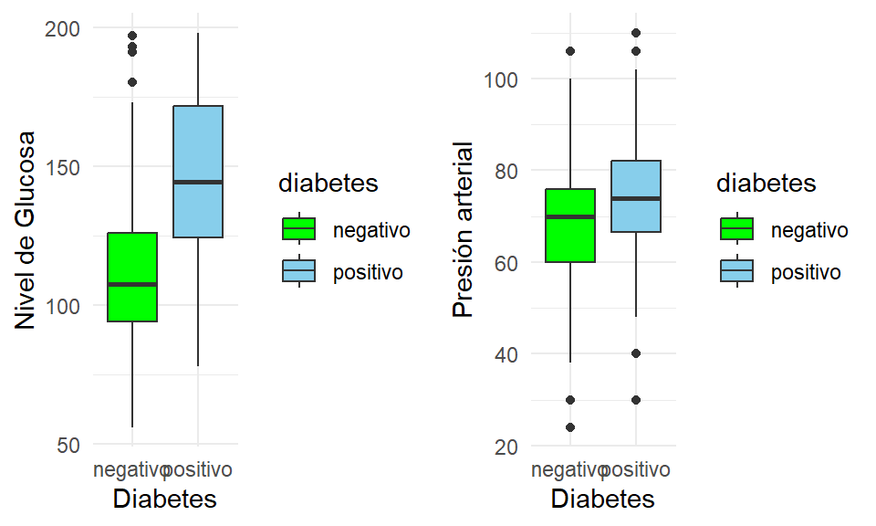

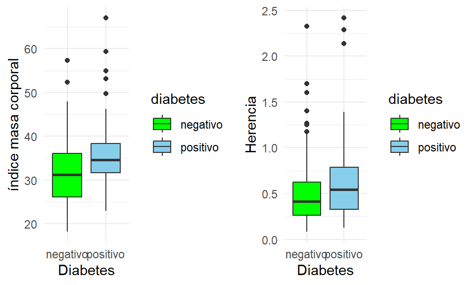

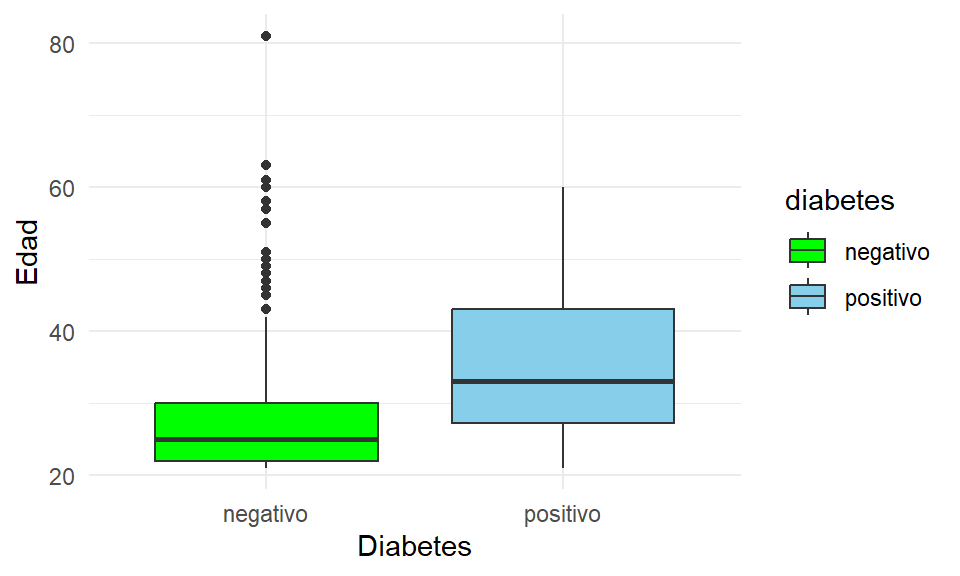

En las gráficas, podemos observar cómo los cuadros azules se sitúan más arriba que los verdes, lo que indica que, a medida que estas variables aumentan, también incrementa la probabilidad de desarrollar la enfermedad.